# Biomass_Basic_Berries

Celeste Basken

2026-01-27

# Berries

```r
# Loading in data to explore
berries <- read.csv("Biomass/Berry_Weights.csv")

berries <- berries %>%
  mutate(
    Inoculation = factor(Inoculation),
    Polyculture = factor(Polyculture),
    Group = interaction(Inoculation, Polyculture, sep = "_")
  )

# Adding a column for continuous water weights: based on the assumption that the emitters are 2 gal/hr

berries <- berries %>%
  mutate(
    Water_gal_per_wk = case_when(
      Water == "Control"  ~ 48,
      Water == "Moderate" ~ 32,
      Water == "Severe"   ~ 16,
      TRUE ~ NA_real_
    )
  )
```

## Part 1: Pretty basic figures

Clustering without regard to PPT:

- Just a note here: I’m using Biomass_g_pp, which is grams per plant of wheat berries. THIS IS IMPORTANT because I forgot to do it at first which meant half the treatments were doubled since this should be considered per capita. Alas.

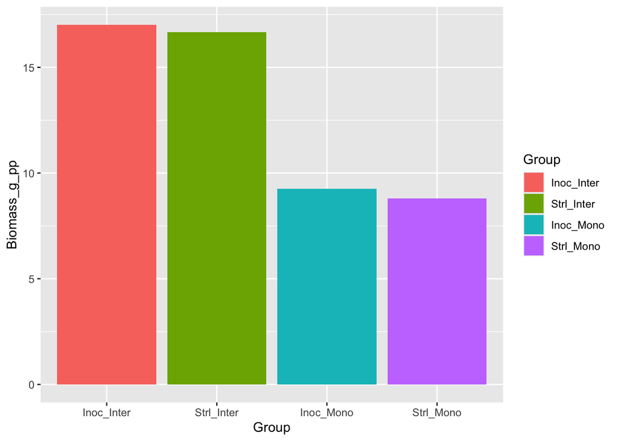

- In the most basic analysis, the monoculture was about half as productive

The same data is below, but with each pot plotted so you can see the variation within the treatments:

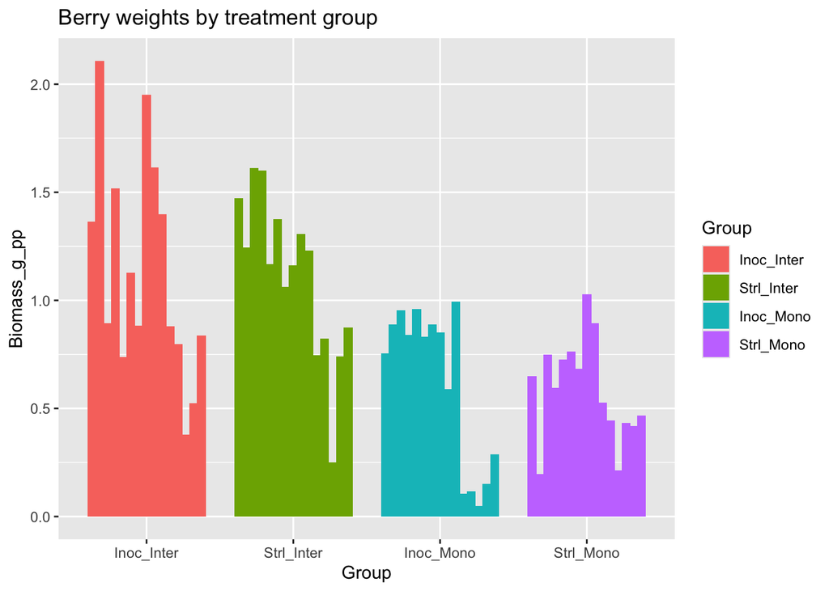

## Part 2: Looking at PPT and what the general behavior is

To begin, here’s what I would EXPECT the graph to look like:

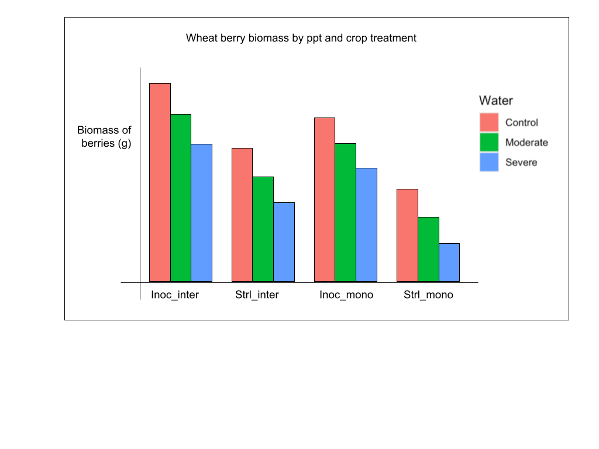

```r
knitr::include_graphics("Biomass/Berries/expected.png")
```

Here’s the actual figure with the data:

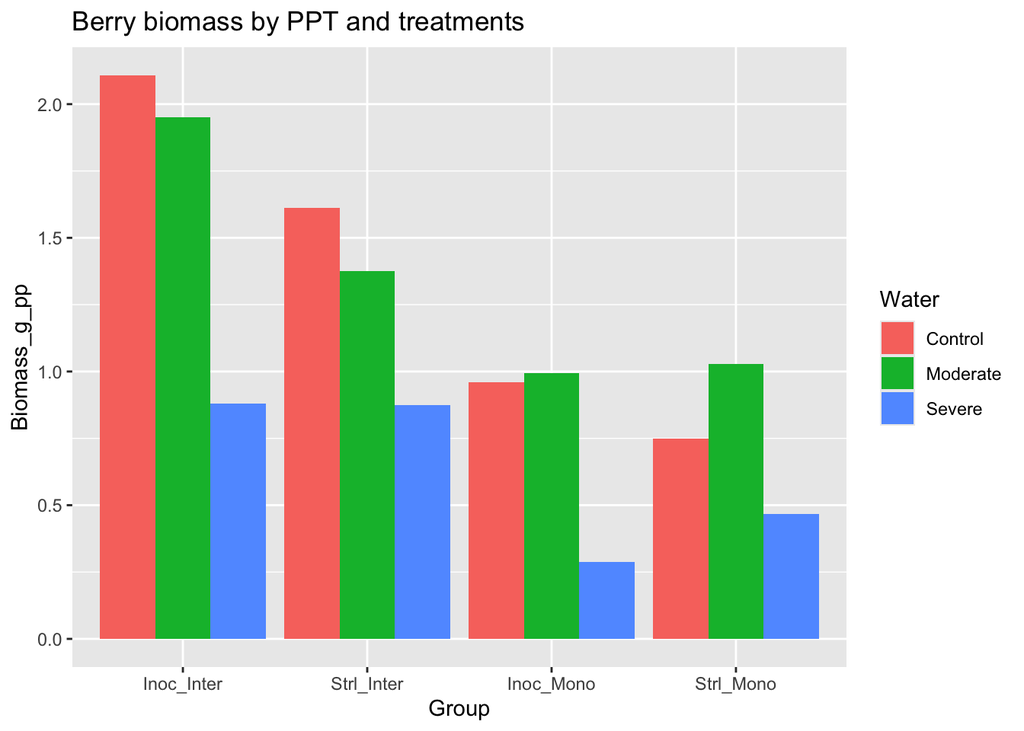

Takeaways

- The Inoc_inter and strl_inter groups are behaving as expected, but the inoc_mono and strl_mono are not (especially strl_mono, which is interesting since it is to an extreme of our treatments)
- This may be explained by intercropping vs monocropping, potentially
- Inoculation seems less significant than intercropping at first pass.
- This kind of makes sense, since that factor is less straightforward. Plus, intercropped plants probably had more room, since the faba didn’t do so well.

## Analyzing these berry biomass trends more in depth

All of the treatments together looking at water: both as a bar graph and boxplot

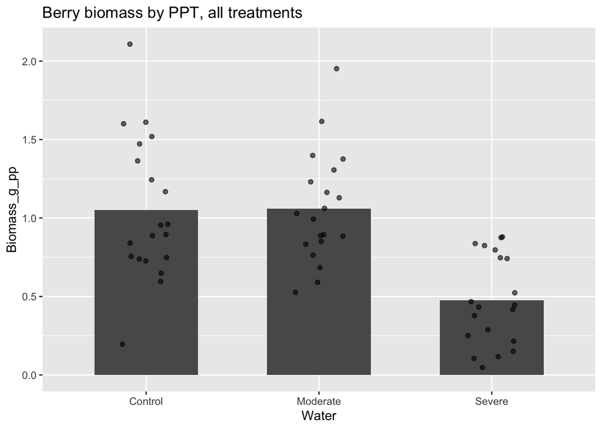

```r
# Bar graph looking at water with the individual points plotted on trop
ggplot(berries, aes(x = Water, y = Biomass_g_pp)) +
  stat_summary(fun = mean, geom = "col", width = 0.6) +
  geom_jitter(width = 0.15, alpha = 0.6) +
  ggtitle("Berry biomass by PPT, all treatments")
```

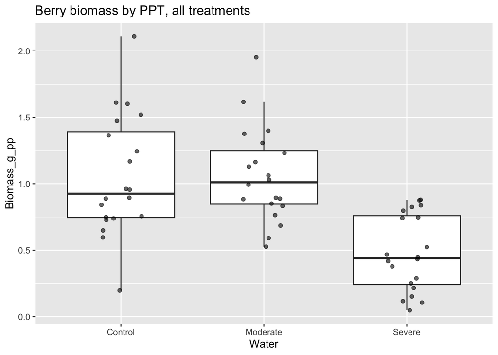

```r
# The same thing (kind of) but as a boxplot with the scattered points

#This code is redundant but good for copy paste later?
berries <- berries %>%
  mutate(
    Water = factor(Water, levels = c("Control", "Moderate", "Severe"))
  )

# The plot
ggplot(berries, aes(x = Water, y = Biomass_g_pp)) +
  geom_boxplot(outlier.shape = NA) +
  geom_jitter(width = 0.15, alpha = 0.6) +
  ggtitle("Berry biomass by PPT, all treatments")
```

Takeaways

- There is a difference between severe compared to control and moderate, but not really within control and moderate
- Can I average the control and moderate somehow? Should I? Or should I just remove moderate and have 2 levels of PPT.

## Focusing on crop diversity: inter vs mono

Since the main difference in expectation vs data for the berry biomass was in the monocropped treatments, I decided to break down these boxplots by cropping diversity. Here are the individual boxplots, and then side by side:

These first figures combine inoc and strl. First, just monocropped:

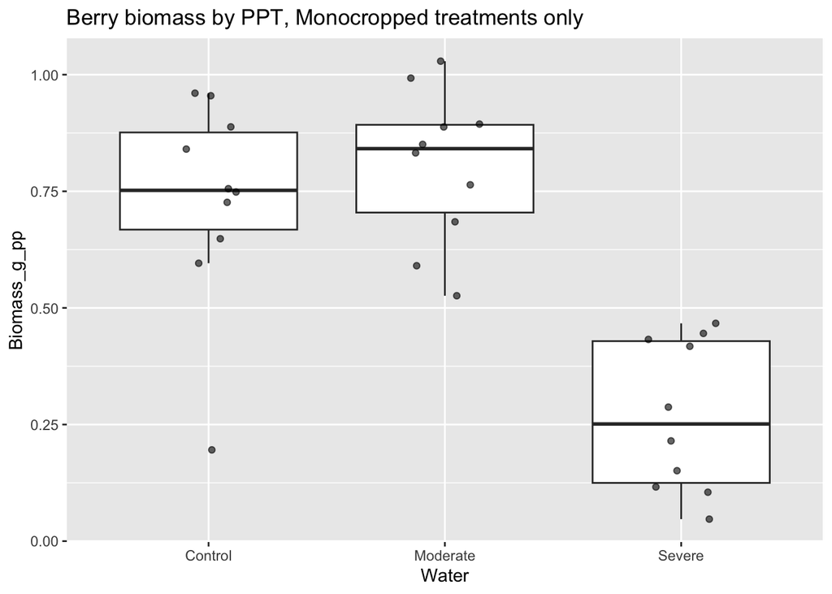

```r
# Looking at just monocropped

berries <- berries %>%
  mutate(
    Water = factor(Water, levels = c("Control", "Moderate", "Severe")),
    Inoculation = factor(Inoculation),
    Polyculture = factor(Polyculture)
  )

berries_inter <- berries %>%
  filter(Polyculture == "Mono")

ggplot(berries_inter, aes(x = Water, y = Biomass_g_pp)) +
  geom_boxplot(outlier.shape = NA) +
  geom_jitter(width = 0.15, alpha = 0.6) +
  ggtitle("Berry biomass by PPT, Monocropped treatments only")
```

And looking at intercropped

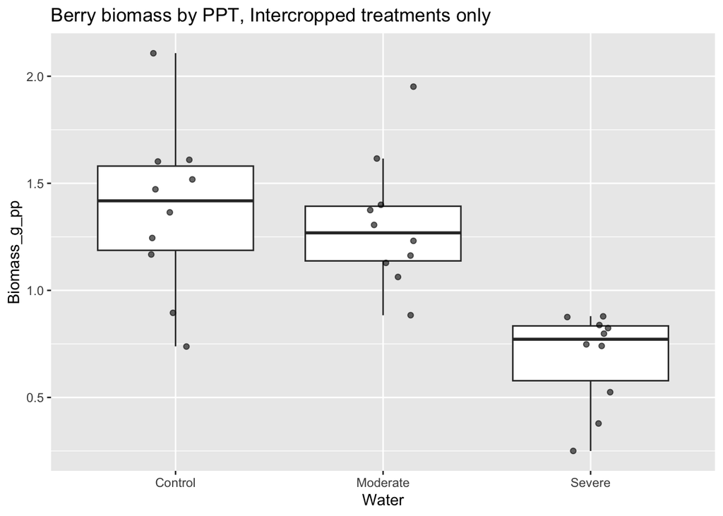

```r
# Looking at just intercropped

berries <- berries %>%
  mutate(
    Water = factor(Water, levels = c("Control", "Moderate", "Severe")),
    Inoculation = factor(Inoculation),
    Polyculture = factor(Polyculture)
  )

berries_inter <- berries %>%
  filter(Polyculture == "Inter")

ggplot(berries_inter, aes(x = Water, y = Biomass_g_pp)) +
  geom_boxplot(outlier.shape = NA) +
  geom_jitter(width = 0.15, alpha = 0.6) +
  ggtitle("Berry biomass by PPT, Intercropped treatments only")
```

Let’s see that side by side and broken down by inoculation status as well

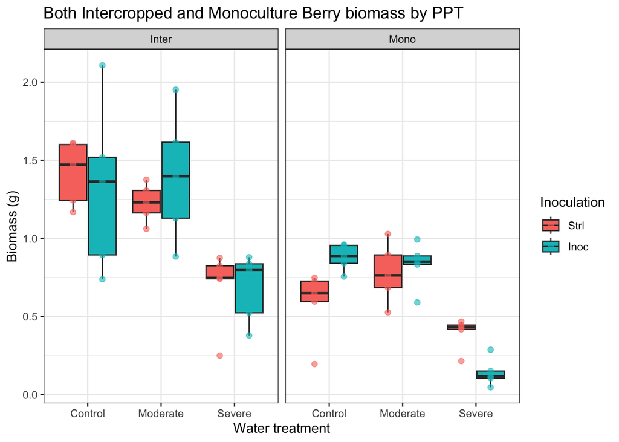

```r
# Splitting it by crop treatment

berries <- berries %>%
  mutate(
    Water       = factor(Water, levels = c("Control", "Moderate", "Severe")),
    Inoculation = factor(Inoculation, levels = c("Strl", "Inoc")),
    Polyculture = factor(Polyculture, levels = c("Inter", "Mono"))
  )

ggplot(berries, aes(x = Water, y = Biomass_g_pp, fill = Inoculation)) +
  geom_boxplot(
    outlier.shape = NA,
    position = position_dodge(width = 0.8)
  ) +
  geom_point(
    aes(color = Inoculation),
    alpha = 0.6,
    size = 1.8,
    position = position_dodge(width = 0.8)
  ) +
  facet_wrap(~ Polyculture) +
  theme_bw() +
  labs(
    x = "Water treatment",
    y = "Biomass (g)"
  ) +
  ggtitle("Both Intercropped and Monoculture Berry biomass by PPT")
```

Takeaways

- The intercropped treatments behave more like I expected (confirming first graph)
- In no treatment is there a real difference between control and moderate PPT. It may have to be dropped, if that’s allowed? Unless there is another solution.
- On the bright side, the severe drought worked!

## Berry statistics

To conclude my berry work, let’s generate some statistics

Before I begin I want to check some assumptions of a t-test!!

The boxes shouldn’t have overly long tails or outliers. The residuals should be straight. These assumptions seem to be met (??).

- I worry that that the residuals look too S-shaped

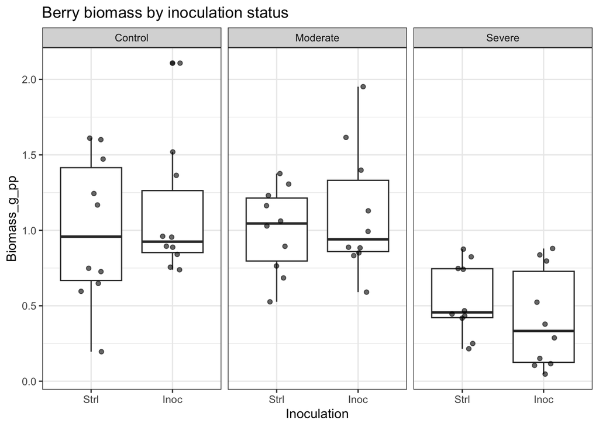

```r
# Check of distributions
ggplot(berries, aes(x = Inoculation, y = Biomass_g_pp)) +
  geom_boxplot() +
  geom_jitter(width = 0.15, alpha = 0.6) +
  facet_wrap(~ Water) +
  theme_bw() +
  ggtitle("Berry biomass by inoculation status")
```

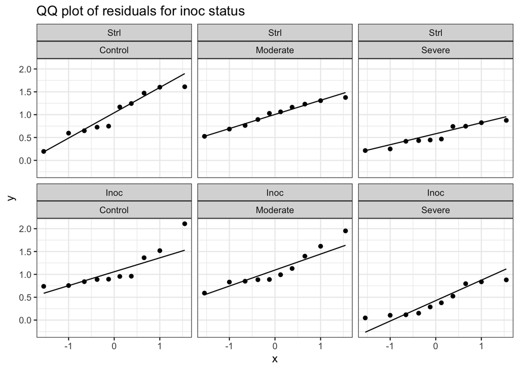

```r
# Q–Q plots of residuals
ggplot(berries, aes(sample = Biomass_g_pp)) +
  stat_qq() +
  stat_qq_line() +
  facet_wrap(~ Inoculation + Water) +
  theme_bw() +
  ggtitle("QQ plot of residuals for inoc status")
```

This next section is generating a variety of summary statistics about the data, and then saving them as CSVs.

```r
# Load + clean
berries <- berries %>%
  mutate(
    Inoculation = factor(Inoculation, levels = c("Strl", "Inoc")),
    Polyculture = factor(Polyculture, levels = c("Mono", "Inter")),
    Water = factor(Water, levels = c("Control", "Moderate", "Severe"))
  ) %>%
  filter(!is.na(Biomass_g_pp))

# Descriptive statistics
desc_stats <- function(x) {
  tibble(
    n      = sum(!is.na(x)),
    mean   = mean(x, na.rm = TRUE),
    sd     = sd(x, na.rm = TRUE),
    se     = sd(x, na.rm = TRUE) / sqrt(sum(!is.na(x))),
    median = median(x, na.rm = TRUE),
    q25    = quantile(x, 0.25, na.rm = TRUE, names = FALSE),
    q75    = quantile(x, 0.75, na.rm = TRUE, names = FALSE),
    iqr    = IQR(x, na.rm = TRUE),
    min    = min(x, na.rm = TRUE),
    max    = max(x, na.rm = TRUE)
  )
}

# Each of the 4 treatments within each Water level
summary_4treat_by_water <- berries %>%
  group_by(Water, Inoculation, Polyculture) %>%
  summarise(desc_stats(Biomass_g_pp), .groups = "drop")

# Inoculation only (fold inter/mono together), within each Water
summary_inoc_by_water <- berries %>%
  group_by(Water, Inoculation) %>%
  summarise(desc_stats(Biomass_g_pp), .groups = "drop")

# Polyculture only (fold inoc/strl together), within each Water
summary_poly_by_water <- berries %>%
  group_by(Water, Polyculture) %>%
  summarise(desc_stats(Biomass_g_pp), .groups = "drop")

# Oerall summaries across Water (all data)
summary_4treat_overall <- berries %>%
  group_by(Inoculation, Polyculture) %>%
  summarise(desc_stats(Biomass_g_pp), .groups = "drop")

summary_inoc_overall <- berries %>%
  group_by(Inoculation) %>%
  summarise(desc_stats(Biomass_g_pp), .groups = "drop")

summary_poly_overall <- berries %>%
  group_by(Polyculture) %>%
  summarise(desc_stats(Biomass_g_pp), .groups = "drop")


# Looking at them as tables
summary_4treat_by_water
```

```
## # A tibble: 12 × 13
##    Water    Inoculation Polyculture     n  mean     sd     se median   q25   q75
##    <fct>    <fct>       <fct>       <int> <dbl>  <dbl>  <dbl>  <dbl> <dbl> <dbl>
##  1 Control  Strl        Mono            5 0.583 0.225  0.101   0.648 0.596 0.726
##  2 Control  Strl        Inter           5 1.42  0.204  0.0912  1.47  1.24  1.60
##  3 Control  Inoc        Mono            5 0.880 0.0854 0.0382  0.888 0.840 0.955
##  4 Control  Inoc        Inter           5 1.32  0.544  0.243   1.36  0.895 1.52
##  5 Moderate Strl        Mono            5 0.779 0.193  0.0863  0.764 0.685 0.894
##  6 Moderate Strl        Inter           5 1.23  0.122  0.0548  1.23  1.16  1.31
##  7 Moderate Inoc        Mono            5 0.831 0.148  0.0662  0.851 0.832 0.888
##  8 Moderate Inoc        Inter           5 1.40  0.416  0.186   1.40  1.13  1.62
##  9 Severe   Strl        Mono            5 0.395 0.103  0.0458  0.433 0.418 0.445
## 10 Severe   Strl        Inter           5 0.688 0.251  0.112   0.747 0.742 0.824
## 11 Severe   Inoc        Mono            5 0.141 0.0898 0.0402  0.116 0.105 0.151
## 12 Severe   Inoc        Inter           5 0.683 0.220  0.0984  0.797 0.524 0.837
## # ℹ 3 more variables: iqr <dbl>, min <dbl>, max <dbl>
```

```r
summary_inoc_by_water
```

```
## # A tibble: 6 × 12
##   Water    Inoculation     n  mean    sd     se median   q25   q75   iqr    min
##   <fct>    <fct>       <int> <dbl> <dbl>  <dbl>  <dbl> <dbl> <dbl> <dbl>  <dbl>
## 1 Control  Strl           10 1.00  0.485 0.153   0.958 0.668 1.42  0.747 0.196
## 2 Control  Inoc           10 1.10  0.435 0.138   0.925 0.852 1.26  0.411 0.738
## 3 Moderate Strl           10 1.00  0.281 0.0889  1.05  0.796 1.21  0.418 0.526
## 4 Moderate Inoc           10 1.11  0.419 0.132   0.940 0.859 1.33  0.472 0.590
## 5 Severe   Strl           10 0.542 0.237 0.0751  0.456 0.421 0.746 0.324 0.215
## 6 Severe   Inoc           10 0.412 0.327 0.103   0.333 0.125 0.728 0.603 0.0472
## # ℹ 1 more variable: max <dbl>
```

```r
summary_poly_by_water
```

```
## # A tibble: 6 × 12
##   Water    Polyculture     n  mean    sd     se median   q25   q75   iqr    min
##   <fct>    <fct>       <int> <dbl> <dbl>  <dbl>  <dbl> <dbl> <dbl> <dbl>  <dbl>
## 1 Control  Mono           10 0.731 0.224 0.0709  0.752 0.668 0.876 0.208 0.196
## 2 Control  Inter          10 1.37  0.390 0.123   1.42  1.19  1.58  0.394 0.738
## 3 Moderate Mono           10 0.805 0.164 0.0520  0.841 0.704 0.893 0.188 0.526
## 4 Moderate Inter          10 1.31  0.302 0.0955  1.27  1.14  1.39  0.255 0.884
## 5 Severe   Mono           10 0.268 0.162 0.0512  0.251 0.125 0.429 0.304 0.0472
## 6 Severe   Inter          10 0.685 0.223 0.0704  0.772 0.578 0.834 0.256 0.250
## # ℹ 1 more variable: max <dbl>
```

```r
# Saving these as csvs

write.csv(summary_4treat_by_water,
          file.path(("Biomass/Berries"), "summary_4treat_by_water.csv"),
          row.names = FALSE)

write.csv(summary_inoc_by_water,
          file.path(("Biomass/Berries"), "summary_inoc_by_water.csv"),
          row.names = FALSE)

write.csv(summary_poly_by_water,
          file.path(("Biomass/Berries"), "summary_poly_by_water.csv"),
          row.names = FALSE)

write.csv(summary_4treat_overall,
          file.path(("Biomass/Berries"), "summary_4treat_overall.csv"),
          row.names = FALSE)

write.csv(summary_inoc_overall,
          file.path(("Biomass/Berries"), "summary_inoc_overall.csv"),
          row.names = FALSE)

write.csv(summary_poly_overall,
          file.path(("Biomass/Berries"), "summary_poly_overall.csv"),
          row.names = FALSE)
```

## Berry statistical analysis

I used AI to generate stats. This should be verified for sure!! Especially to make sure I meet the assumptions to even be using these stats.

```r
# These statistics were Chat GPT and should be verified

# P-VALUES: Simple comparisons within each Water ----
# Welch t-tests are robust to unequal variances (default in t.test)

# a) Inoculation effect within each Water (folding Polyculture)
ttest_inoc_within_water <- berries %>%
  group_by(Water) %>%
  do(tidy(t.test(Biomass_g_pp ~ Inoculation, data = .))) %>%
  ungroup() %>%
  select(Water, estimate1, estimate2, statistic, p.value, conf.low, conf.high, method)

# b) Polyculture effect within each Water (folding Inoculation)
ttest_poly_within_water <- berries %>%
  group_by(Water) %>%
  do(tidy(t.test(Biomass_g_pp ~ Polyculture, data = .))) %>%
  ungroup() %>%
  select(Water, estimate1, estimate2, statistic, p.value, conf.low, conf.high, method)

# ---- 3-way factorial model (lets you test interactions) ----
# If your data are fairly normal-ish, this is a strong default.
fit_aov <- aov(Biomass_g_pp ~ Inoculation * Polyculture * Water, data = berries)
aov_table <- broom::tidy(fit_aov)

# ---- Optional: Nonparametric alternatives (in case assumptions are shaky) ----
# Wilcoxon rank-sum within each Water for Inoculation / Polyculture
wilcox_inoc_within_water <- berries %>%
  group_by(Water) %>%
  do(tidy(wilcox.test(Biomass_g_pp ~ Inoculation, data = ., exact = FALSE))) %>%
  ungroup() %>%
  select(Water, statistic, p.value, method)

wilcox_poly_within_water <- berries %>%
  group_by(Water) %>%
  do(tidy(wilcox.test(Biomass_g_pp ~ Polyculture, data = ., exact = FALSE))) %>%
  ungroup() %>%
  select(Water, statistic, p.value, method)

# Print these

ttest_inoc_within_water
```

```
## # A tibble: 3 × 8
##   Water    estimate1 estimate2 statistic p.value conf.low conf.high method
##   <fct>        <dbl>     <dbl>     <dbl>   <dbl>    <dbl>     <dbl> <chr>
## 1 Control      1.00      1.10     -0.492   0.629   -0.535     0.332 Welch Two S…
## 2 Moderate     1.00      1.11     -0.688   0.501   -0.448     0.229 Welch Two S…
## 3 Severe       0.542     0.412     1.01    0.325   -0.141     0.399 Welch Two S…
```

```r
ttest_poly_within_water
```

```
## # A tibble: 3 × 8
##   Water    estimate1 estimate2 statistic  p.value conf.low conf.high method
##   <fct>        <dbl>     <dbl>     <dbl>    <dbl>    <dbl>     <dbl> <chr>
## 1 Control      0.731     1.37      -4.50 0.000468   -0.945    -0.336 Welch Two …
## 2 Moderate     0.805     1.31      -4.66 0.000377   -0.740    -0.273 Welch Two …
## 3 Severe       0.268     0.685     -4.79 0.000186   -0.601    -0.233 Welch Two …
```

```r
aov_table
```

```
## # A tibble: 8 × 6
##   term                             df    sumsq   meansq statistic   p.value
##   <chr>                         <dbl>    <dbl>    <dbl>     <dbl>     <dbl>
## 1 Inoculation                       1 0.0111   0.0111     0.173    6.79e- 1
## 2 Polyculture                       1 4.08     4.08      63.4      2.51e-10
## 3 Water                             2 4.46     2.23      34.7      4.84e-10
## 4 Inoculation:Polyculture           1 0.000252 0.000252   0.00392  9.50e- 1
## 5 Inoculation:Water                 2 0.184    0.0921     1.43     2.49e- 1
## 6 Polyculture:Water                 2 0.127    0.0634     0.985    3.81e- 1
## 7 Inoculation:Polyculture:Water     2 0.286    0.143      2.22     1.19e- 1
## 8 Residuals                        48 3.09     0.0643    NA       NA
```

```r
# Saving as CSV

write.csv(ttest_inoc_within_water,
          file.path(("Biomass/Berries/Stats"), "ttest_inoc_within_water.csv"),
          row.names = FALSE)

write.csv(ttest_poly_within_water,
          file.path(("Biomass/Berries/Stats"), "ttest_poly_within_water.csv"),
          row.names = FALSE)

write.csv(aov_table,
          file.path(("Biomass/Berries/Stats"), "anova_3way_table.csv"),
          row.names = FALSE)

write.csv(wilcox_inoc_within_water,
          file.path(("Biomass/Berries/Stats"), "wilcox_inoc_within_water.csv"),
          row.names = FALSE)

write.csv(wilcox_poly_within_water,
          file.path(("Biomass/Berries/Stats"), "wilcox_poly_within_water.csv"),
          row.names = FALSE)
```